# Customer Segmentation Analysis

## Introduction

In this project, we will perform customer segmentation analysis using machine learning and K-means clustering algorithm. Customer segmentation analysis helps businesses identify potential customer groups, allowing business to tailor marketing and business strategies to each specific group.

## Load Libraries

```r
library(ggplot2)
library(dplyr)
library(purrr)
```

## Data Exploration

```r
customer_data=read.csv("D:/Coding/R for Data Science/customer-segmentation-dataset/Mall_Customers.csv")
str(customer_data)
```

```
'data.frame':   200 obs. of  5 variables:
 $ CustomerID            : int  1 2 3 4 5 6 7 8 9 10 ...
 $ Gender                : chr  "Male" "Male" "Female" "Female" ...
 $ Age                   : int  19 21 20 23 31 22 35 23 64 30 ...
 $ Annual.Income..k..    : int  15 15 16 16 17 17 18 18 19 19 ...
 $ Spending.Score..1.100.: int  39 81 6 77 40 76 6 94 3 72 ...
```

We have a data.frame with 5 columns and 200 rows. Four are ‘int’ data type and one string data type.

```r
names(customer_data)
```

```
[1] "CustomerID"             "Gender"                 "Age"                    "Annual.Income..k.."
[5] "Spending.Score..1.100."
```

```r
head(customer_data)
```

|  | CustomerID | Gender | Age | Annual.Income..k.. | Spending.Score..1.100. |
| --- | --- | --- | --- | --- | --- |
| 1 | 1 | Male | 19 | 15 | 39 |
| 2 | 2 | Male | 21 | 15 | 81 |
| 3 | 3 | Female | 20 | 16 | 6 |
| 4 | 4 | Female | 23 | 16 | 77 |
| 5 | 5 | Female | 31 | 17 | 40 |
| 6 | 6 | Female | 22 | 17 | 76 |

```r
summary(customer_data)
```

```
   CustomerID        Gender               Age        Annual.Income..k.. Spending.Score..1.100.
 Min.   :  1.00   Length:200         Min.   :18.00   Min.   : 15.00     Min.   : 1.00
 1st Qu.: 50.75   Class :character   1st Qu.:28.75   1st Qu.: 41.50     1st Qu.:34.75
 Median :100.50   Mode  :character   Median :36.00   Median : 61.50     Median :50.00
 Mean   :100.50                      Mean   :38.85   Mean   : 60.56     Mean   :50.20
 3rd Qu.:150.25                      3rd Qu.:49.00   3rd Qu.: 78.00     3rd Qu.:73.00
 Max.   :200.00                      Max.   :70.00   Max.   :137.00     Max.   :99.00
```

```r
sum(is.null(customer_data))
```

```
[1] 0
```

The data set is already clean with no null values. The min and max value of each int category appears to be clean too.

```r
sd(customer_data$Age)
```

```
[1] 13.96901
```

```r
summary(customer_data$Annual.Income..k..)
```

```
   Min. 1st Qu.  Median    Mean 3rd Qu.    Max.
  15.00   41.50   61.50   60.56   78.00  137.00
```

```r
sd(customer_data$Annual.Income..k..)
```

```
[1] 26.26472
```

```r
summary(customer_data$Age)
```

```
   Min. 1st Qu.  Median    Mean 3rd Qu.    Max.
  18.00   28.75   36.00   38.85   49.00   70.00
```

```r
sd(customer_data$Spending.Score..1.100.)
```

```
[1] 25.82352
```

## Exploratory Data Analysis

#### Gender Analysis

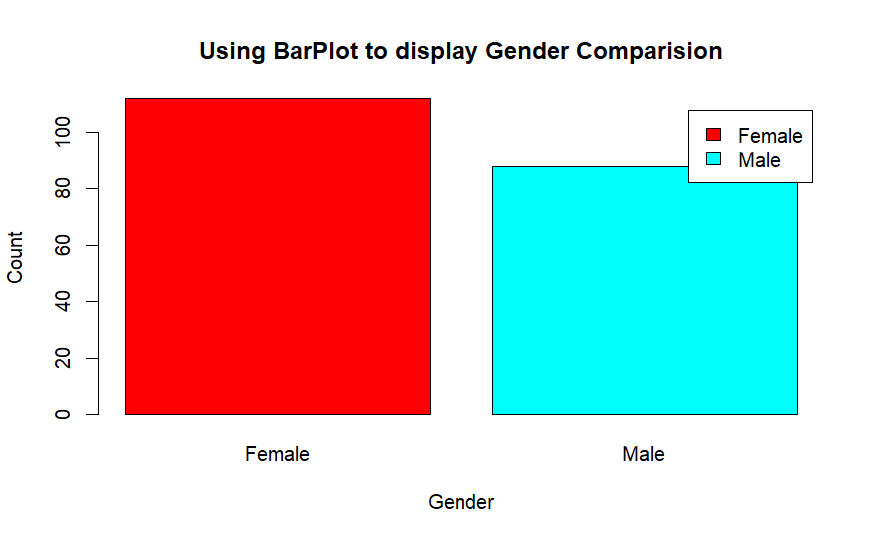

```r
a=table(customer_data$Gender)
barplot(a,main="Using BarPlot to display Gender Comparision",
       ylab="Count",
       xlab="Gender",
       col=rainbow(2),
       legend=rownames(a))
```

We see that there is a higher distribution of females compared to males in our data set.

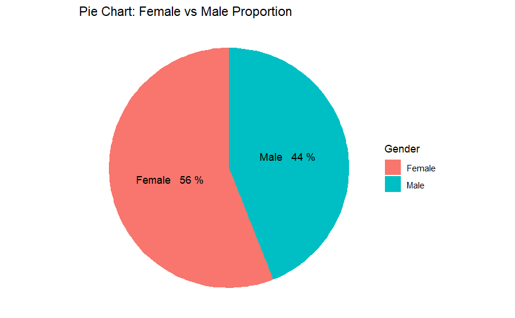

```r
pct=round(a/sum(a)*100)
lbs=paste(c("Female","Male")," ",pct,"%",sep=" ")

gender_data <- customer_data %>%
  group_by(Gender) %>%
    summarise(Total = n())

# Create a plot object
pie_plot <- ggplot(gender_data, aes(x = "Gender", y = Total, fill = Gender)) +
            geom_bar(stat = "identity")

# Convert the bar plot to a pie chart
pie_plot <- pie_plot + coord_polar("y", start = 0)

# Customize appearance
pie_plot <- pie_plot + theme_void() +
            labs(title = "Pie Chart: Female vs Male Proportion", fill = "Gender") +
            geom_text(label=lbs, position=position_stack(vjust=0.5))

# Render the plot
print(pie_plot)
```

The the data set is composed of 56% female gender and 44% male gender.

#### Age Analysis

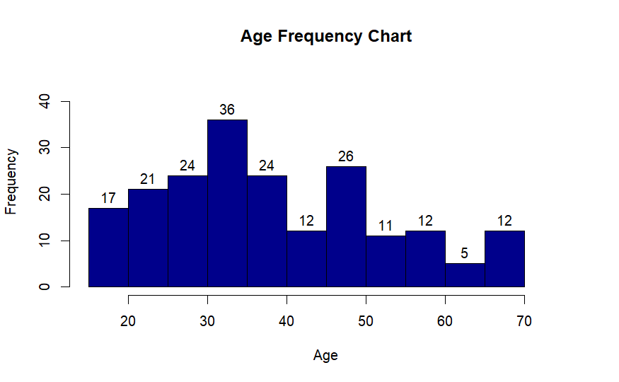

```r
hist(customer_data$Age,
    col="darkblue",
    main="Age Frequency Chart",
    xlab="Age",
    ylab="Frequency",
    ylim = c(0,45),
    xlim = c(15,75),
    labels=TRUE)
```

We see a somewhat normal distribution of the age, but with slight right skew.

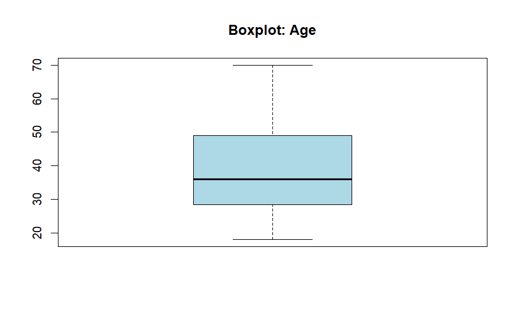

```r
boxplot(customer_data$Age,
       col="lightblue",
       main="Boxplot: Age")
```

#### Annual Income Analysis

```r
summary(customer_data$Annual.Income..k..)
```

```
   Min. 1st Qu.  Median    Mean 3rd Qu.    Max.
  15.00   41.50   61.50   60.56   78.00  137.00
```

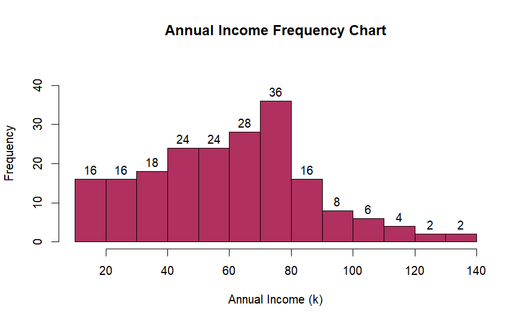

```r
hist(customer_data$Annual.Income..k..,
  col="maroon",
  main="Annual Income Frequency Chart",
  xlab="Annual Income (k)",
  ylab="Frequency",
  ylim=c(0,45),
  labels=TRUE)
```

Annual income of around 70k has the highest frequency.

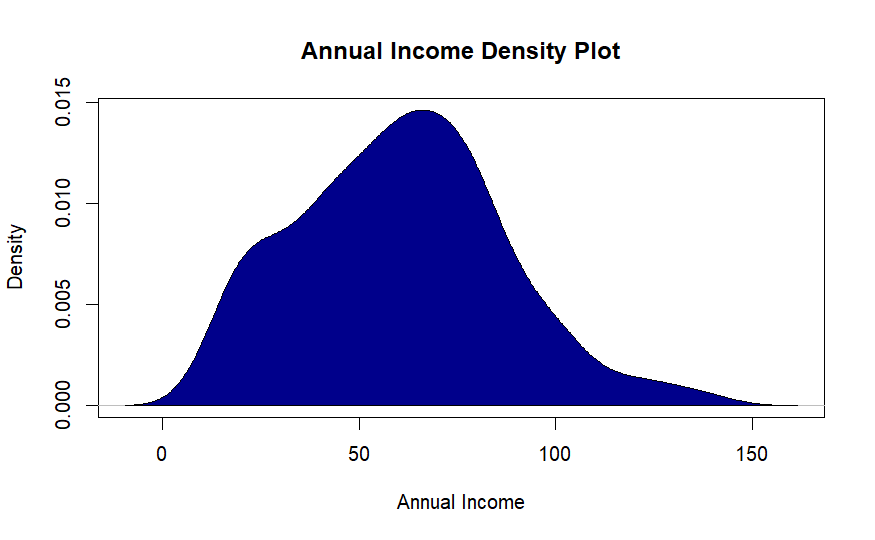

```r
plot(density(customer_data$Annual.Income..k..),
    col="darkblue",
    main="Annual Income Density Plot",
    xlab="Annual Income",
    ylab="Density")
polygon(density(customer_data$Annual.Income..k..),
        col="darkblue")
```

We see that annual income also has a relatively normal distribution with slight right skew.

#### Spending Score Analysis

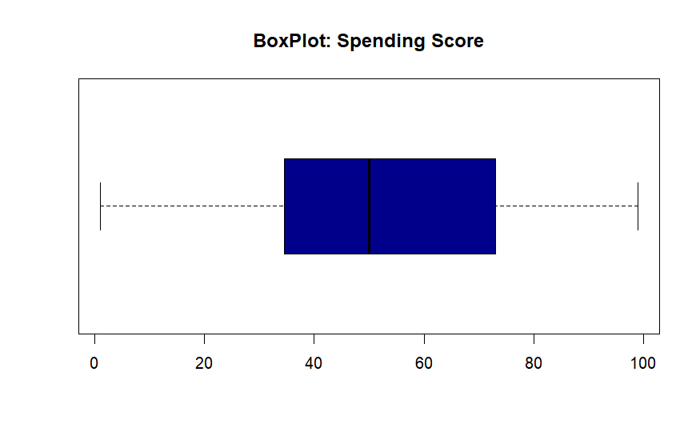

```r
boxplot(customer_data$Spending.Score..1.100.,
   horizontal=TRUE,
   col="darkblue",
   main="BoxPlot: Spending Score")
```

Spending score mean is around 50; minimum at 1, maximum at 99.

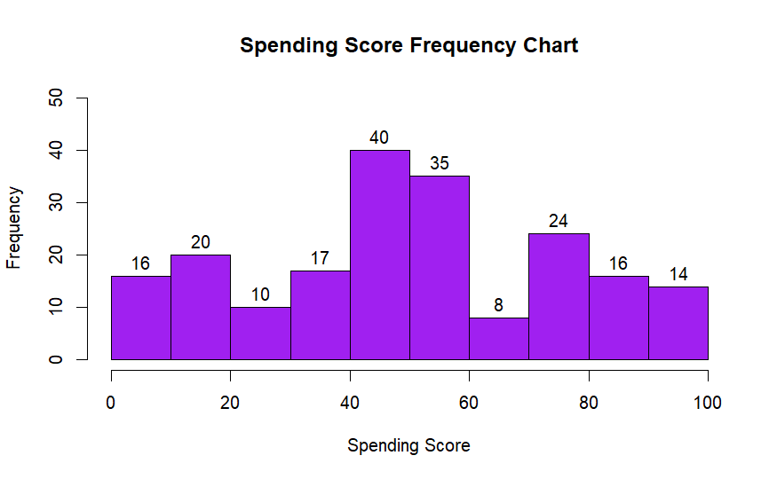

```r
hist(customer_data$Spending.Score..1.100.,
    main="Spending Score Frequency Chart",
    xlab="Spending Score",
    ylab="Frequency",
    col="purple",
    ylim=c(0,50),
    labels=TRUE)
```

Spending score of 40 and 50 have the highest counts.

## Determining K-means Clusters

In the K-means cluster algorithm, the machine learning algorithm will create centroids around a specified number of clusters(k) based on shortest Euclidean Distance. We will explore three different methods of determining the most suitable number of clusters (k).

#### Elbow Method

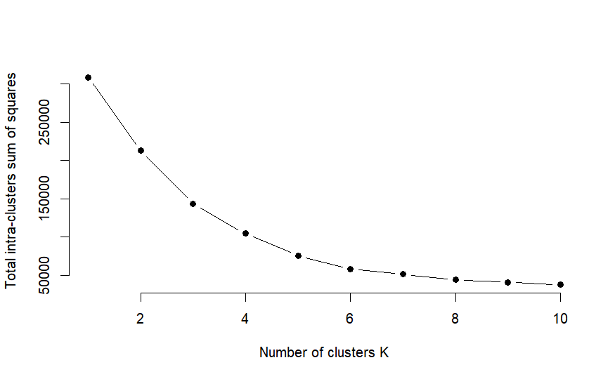

```r
set.seed(123)
intra_square_sum <- function(k) {
  kmeans(customer_data[3:5],k,iter.max=100,nstart=100,algorithm="Lloyd")$tot.withinss
}
k.values <- 1:10

iss_values <- map_dbl(k.values, intra_square_sum)

plot(k.values, iss_values,
     type='b', pch=19, frame=FALSE,
     xlab="Number of clusters K",
     ylab="Total intra-clusters sum of squares")
```

We look at the elbow plot to see where the total intra-clusters sum of square starts to diminish in its decreasing velocity. For the plot above, that would be about K = 4, or the elbow.

#### Silhouette Method

The silhouette method calculates the mean silhouette observations for different k values. The highest average silhouette value signifies the best k value.

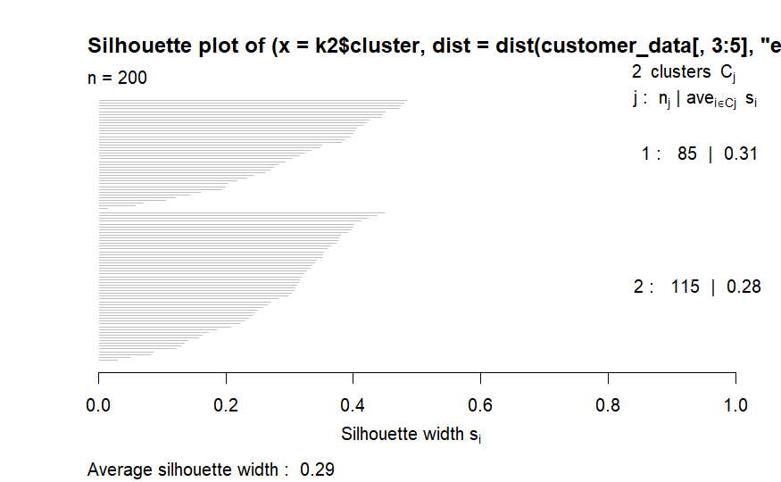

```r
library(cluster)
library(gridExtra)
library(grid)

#k2
k2<-kmeans(customer_data[,3:5],2,iter.max=100,nstart=50,algorithm="Lloyd")
s2<-plot(silhouette(k2$cluster,dist(customer_data[,3:5],"euclidean")))
```

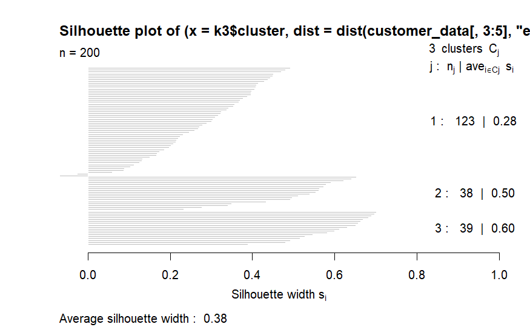

```r
#k3
k3<-kmeans(customer_data[,3:5],3,iter.max=100,nstart=50,algorithm="Lloyd")
s3<-plot(silhouette(k3$cluster,dist(customer_data[,3:5],"euclidean")))
```

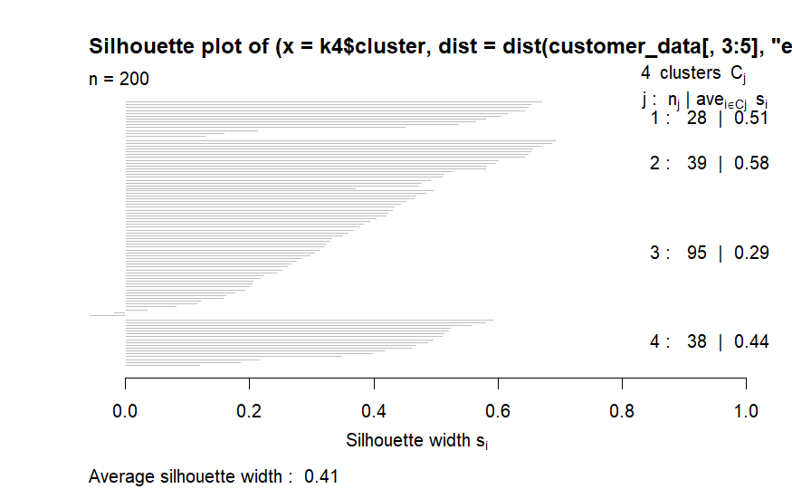

```r
#k4
k4<-kmeans(customer_data[,3:5],4,iter.max=100,nstart=50,algorithm="Lloyd")
s4<-plot(silhouette(k4$cluster,dist(customer_data[,3:5],"euclidean")))
```

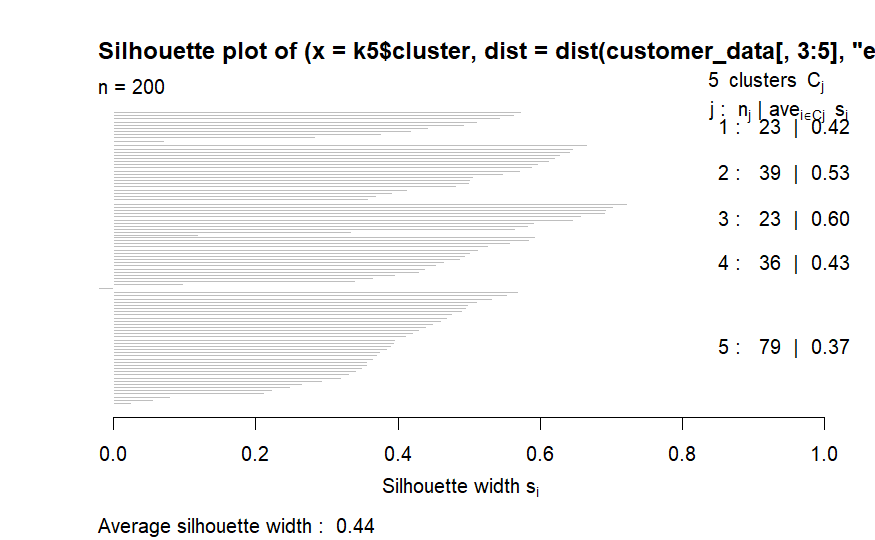

```r
#k5
k5<-kmeans(customer_data[,3:5],5,iter.max=100,nstart=50,algorithm="Lloyd")
s5<-plot(silhouette(k5$cluster,dist(customer_data[,3:5],"euclidean")))
```

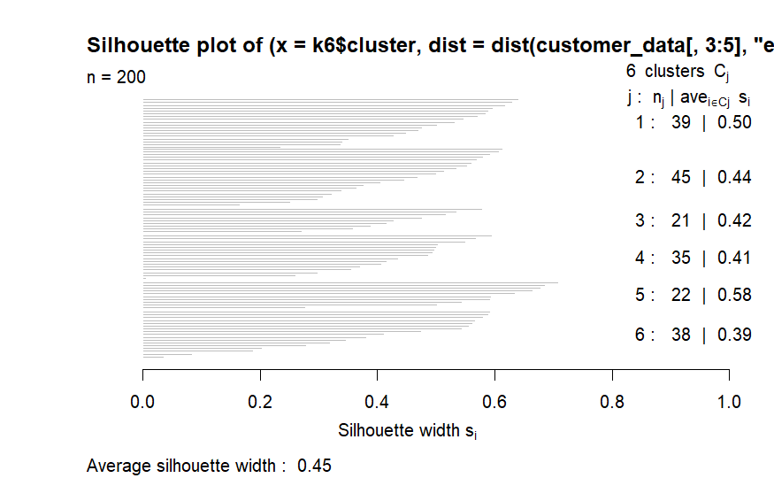

```r
#k6
k6<-kmeans(customer_data[,3:5],6,iter.max=100,nstart=50,algorithm="Lloyd")
s6<-plot(silhouette(k6$cluster,dist(customer_data[,3:5],"euclidean")))
```

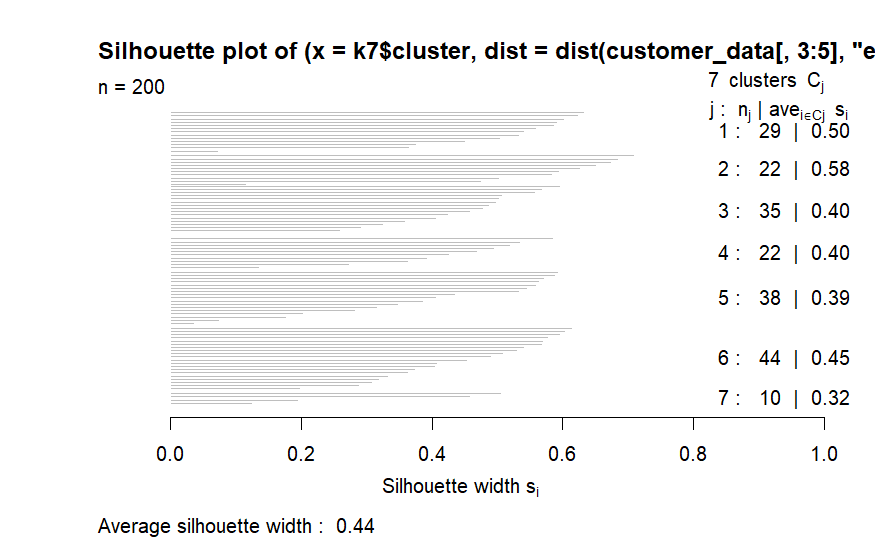

```r
#k7
k7<-kmeans(customer_data[,3:5],7,iter.max=100,nstart=50,algorithm="Lloyd")
s7<-plot(silhouette(k7$cluster,dist(customer_data[,3:5],"euclidean")))
```

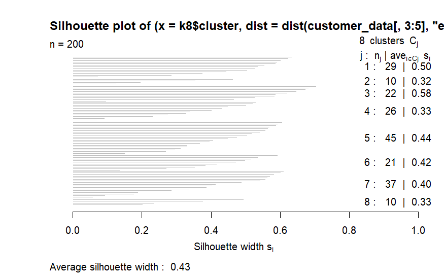

```r
#k8
k8<-kmeans(customer_data[,3:5],8,iter.max=100,nstart=50,algorithm="Lloyd")
s8<-plot(silhouette(k8$cluster,dist(customer_data[,3:5],"euclidean")))
```

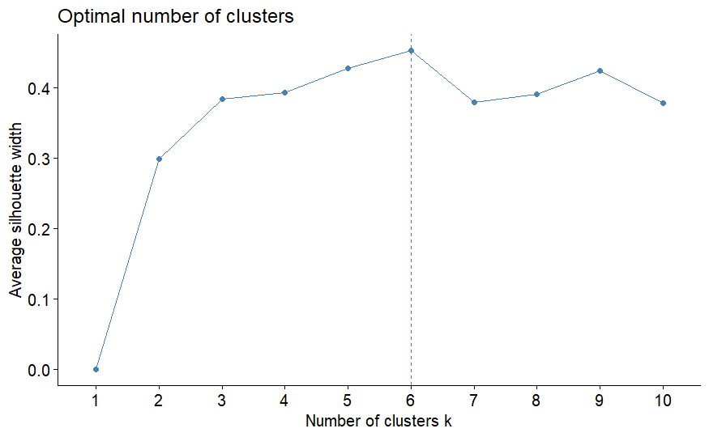

```r
library(NbClust)
library(factoextra)

fviz_nbclust(customer_data[,3:5], kmeans, method = "silhouette")
```

Optimal k from the average silhouette method is 6.

#### Gap Statistic method

The gap statistic method compares variation in the clusters of the actual data set vs a generated random data set (which is generated via Monte Carlo simulations). This ensures ML is not just finding patterns by chance.

```r
set.seed(125)
stat_gap <- clusGap(customer_data[,3:5], FUN = kmeans, nstart = 25,
            K.max = 10, B = 50)
```

```
Clustering k = 1,2,..., K.max (= 10): .. done
Bootstrapping, b = 1,2,..., B (= 50)  [one "." per sample]:
.................................................. 50
```

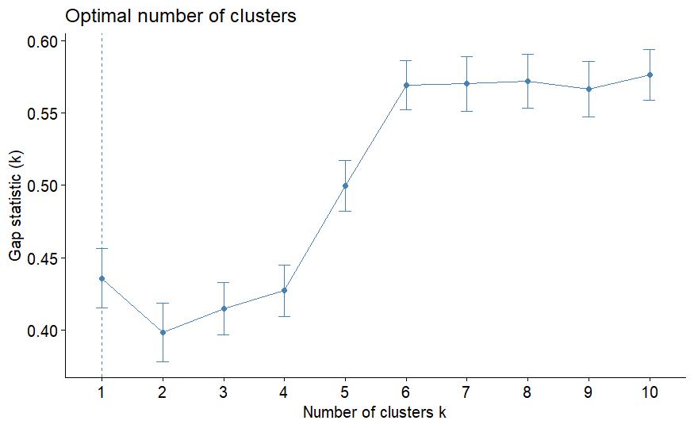

```r
fviz_gap_stat(stat_gap)
```

```r
k6<-kmeans(customer_data[,3:5],6,iter.max=100,nstart=50,algorithm="Lloyd")
k6
```

```
K-means clustering with 6 clusters of sizes 35, 22, 38, 44, 22, 39

Cluster means:
       Age Annual.Income..k.. Spending.Score..1.100.
1 41.68571           88.22857               17.28571
2 44.31818           25.77273               20.27273
3 27.00000           56.65789               49.13158
4 56.34091           53.70455               49.38636
5 25.27273           25.72727               79.36364
6 32.69231           86.53846               82.12821

Clustering vector:
  [1] 2 5 2 5 2 5 2 5 2 5 2 5 2 5 2 5 2 5 2 5 2 5 2 5 2 5 2 5 2 5 2 5 2 5 2 5 2 5 2 5 4 5 2 3 2 5 4 3 3 3 4 3 3 4
 [55] 4 4 4 4 3 4 4 3 4 4 4 3 4 4 3 3 4 4 4 4 4 3 4 3 3 4 4 3 4 4 3 4 4 3 3 4 4 3 4 3 3 3 4 3 4 3 3 4 4 3 4 3 4 4
[109] 4 4 4 3 3 3 3 3 4 4 4 4 3 3 3 6 3 6 1 6 1 6 1 6 3 6 1 6 1 6 1 6 1 6 3 6 1 6 1 6 1 6 1 6 1 6 1 6 1 6 1 6 1 6
[163] 1 6 1 6 1 6 1 6 1 6 1 6 1 6 1 6 1 6 1 6 1 6 1 6 1 6 1 6 1 6 1 6 1 6 1 6 1 6

Within cluster sum of squares by cluster:
[1] 16690.857  8189.000  7742.895  7607.477  4099.818 13972.359
 (between_SS / total_SS =  81.1 %)

Available components:

[1] "cluster"      "centers"      "totss"        "withinss"     "tot.withinss" "betweenss"    "size"
[8] "iter"         "ifault"
```

## Visualizing Our K-clusters

#### Principal Component Analysis

We will reduce dimensionality of our data set before K-clustering visualization. We will apply this to age, annual income, and spending score.

```r
pcclust=prcomp(customer_data[,3:5],scale=FALSE) #principal component analysis
summary(pcclust)
```

```
Importance of components:
                           PC1     PC2     PC3
Standard deviation     26.4625 26.1597 12.9317
Proportion of Variance  0.4512  0.4410  0.1078
Cumulative Proportion   0.4512  0.8922  1.0000
```

We see that PC1 explains 45% of the variance and PC2 explains 44% of the variance. PC3 explains only 10% of the variance.

```r
pcclust$rotation[,1:2]
```

```
                              PC1        PC2
Age                     0.1889742 -0.1309652
Annual.Income..k..     -0.5886410 -0.8083757
Spending.Score..1.100. -0.7859965  0.5739136
```

We proceed to look at the two components that explain most of the variance. Age is positively correlated with PC1. Spending score is positively correlated with PC2.

We will visualize the clusters using PC1 and PC2.

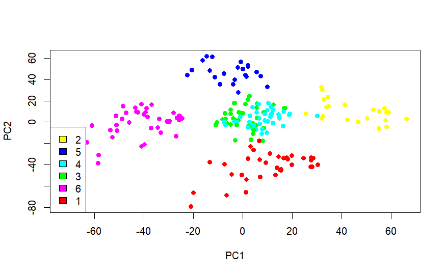

```r
kCols=function(vec){cols=rainbow (length (unique (vec)))
return (cols[as.numeric(as.factor(vec))])}

digCluster<-k6$cluster; dignm<-as.character(digCluster); # K-means clusters

plot(pcclust$x[,1:2], col =kCols(digCluster),pch =19,xlab ="PC1",ylab="PC2")
legend("bottomleft",unique(dignm),fill=unique(kCols(digCluster)))
```

We can see that there are 6 clusters based on our k-means clustering of the PCA components. In terms of business strategy to optimize spending, we may be more interested in clusters with high PC2 as PC2 is positively correlated with spending score. Thus, cluster 5 may be most interesting to that end.

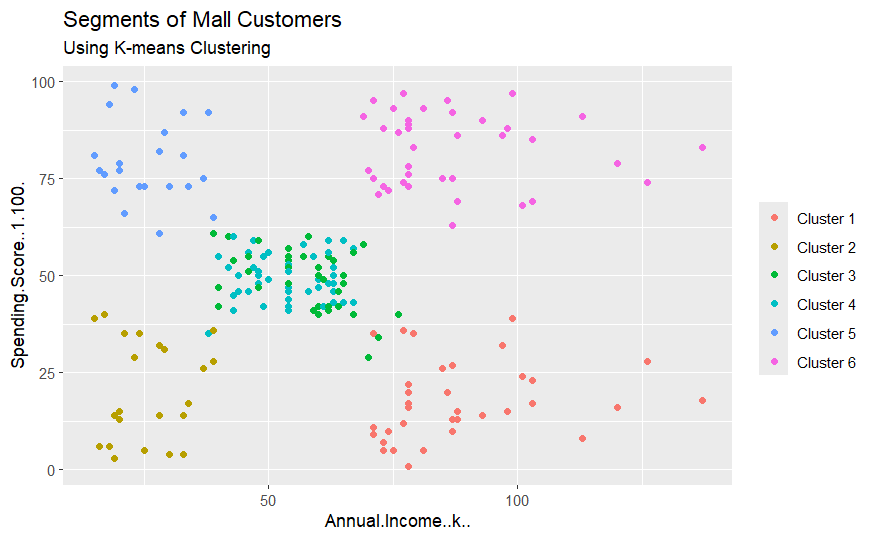

```r
set.seed(1)
ggplot(customer_data, aes(x =Annual.Income..k.., y = Spending.Score..1.100.)) +
  geom_point(stat = "identity", aes(color = as.factor(k6$cluster))) +
  scale_color_discrete(name=" ",
              breaks=c("1", "2", "3", "4", "5","6"),
              labels=c("Cluster 1", "Cluster 2", "Cluster 3", "Cluster 4", "Cluster 5","Cluster 6")) +
  ggtitle("Segments of Mall Customers", subtitle = "Using K-means Clustering")
```

Here we look specifically into spending score and annual income. Cluster 5 shows high spending score, but lower annual income. This information may be relevant to pricing strategies as lower annual income may suggest lower disposal income.

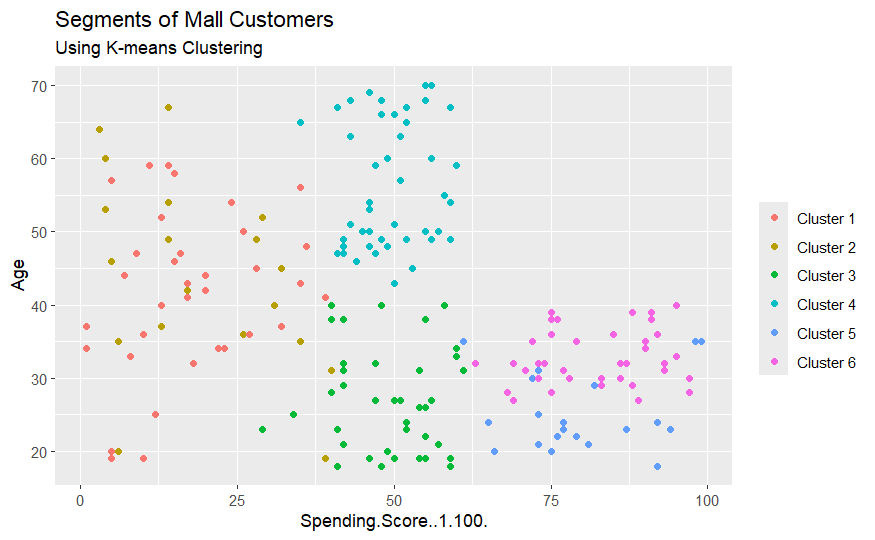

```r
ggplot(customer_data, aes(x =Spending.Score..1.100., y =Age)) +
  geom_point(stat = "identity", aes(color = as.factor(k6$cluster))) +
  scale_color_discrete(name=" ",
                      breaks=c("1", "2", "3", "4", "5","6"),
                      labels=c("Cluster 1", "Cluster 2", "Cluster 3", "Cluster 4", "Cluster 5","Cluster 6")) +
  ggtitle("Segments of Mall Customers", subtitle = "Using K-means Clustering")
```

We see here that cluster 6 tends to be customers from the 20s to 30s group. This may be relevant in our marketing strategy.

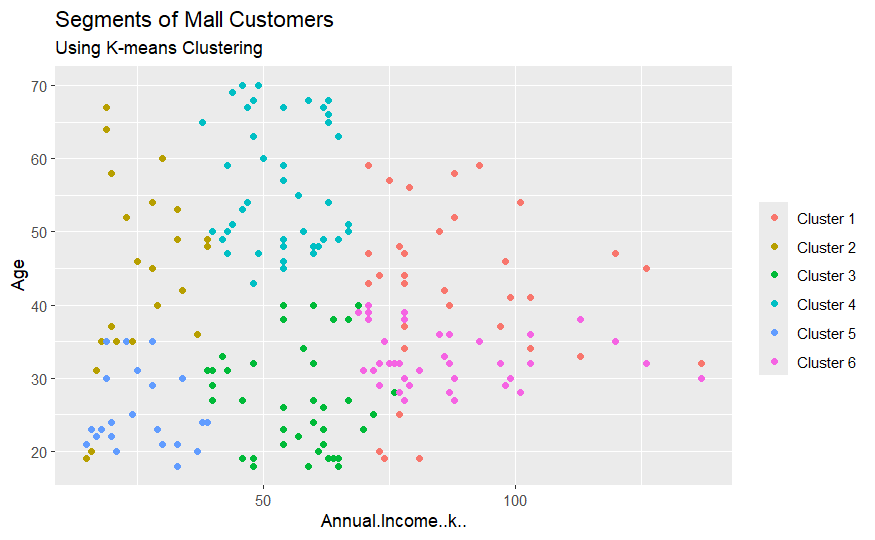

```r
ggplot(customer_data, aes(x =Annual.Income..k.., y =Age)) +
  geom_point(stat = "identity", aes(color = as.factor(k6$cluster))) +
  scale_color_discrete(name=" ",
                      breaks=c("1", "2", "3", "4", "5","6"),
                      labels=c("Cluster 1", "Cluster 2", "Cluster 3", "Cluster 4", "Cluster 5","Cluster 6")) +
  ggtitle("Segments of Mall Customers", subtitle = "Using K-means Clustering")
```

Here we see that cluster 5 tends to be younger in age with lower annual income.

## Conclusion

In this project, we performed unsupervised machine learning via k-means clustering to segment customers for potential business and market strategies.

We learned important characteristics and information of each customer group and potential relationship between their age, annual income, and spending score. We may also consider converting categorical data ie gender into numeric representation ie one-hot encoding, so that we may perform k-clustering on it as well. This may reveal potential for targeted marketing towards each gender if significant differences were found.